# Another example of GAMs

# Preliminaries

In this session, we will complete GAMs by considering another example of Generalised Additive Models. In the last session we showed that in practice, the fitting and inference for Generalised Additive Models (GAMs) is similar to that of Generalised Linear Models (GLMs). This session will show another example of GAMs, and in particular how you might want to model interactions and why sometimes we may need to apply subjective reasoning rather than relying on model inference. All practical aspects will be done using the `munichrent` dataframe. This can be found in `datasets.RData` on the course ELE page and can be loaded into `R` using the `load()` function.

```r
# Loading datasets required
load('datasets.RData')
```

We also need the `mgcv` package which will help us fit Generalised Additive Models. We use the `install.packages()` function to download and install the most recent package and use the `library()` function to load them into the `R` library.

```r
# Installing required packages
#install.packages("mgcv")

# Loading required packages into the library
library(mgcv)
```

# Example: `munichrent` dataframe

```r
# Fist 6 rows of munichrent
head(munichrent)
      rent yearc location district
1 120.9744  1939        1     1112
2 436.9743  1939        1     1112
3 355.7436  1971        2     2114
4 282.9231  1972        2     2148
5 807.2308  1985        1     2222
6 482.8205  1962        1     2222

# Summarising the dataset
summary(munichrent)
      rent             yearc      location    district
 Min.   :  40.51   Min.   :1918   1:1794   411    :  53
 1st Qu.: 322.03   1st Qu.:1939   2:1210   623    :  53
 Median : 426.97   Median :1959   3:  78   350    :  49
 Mean   : 459.44   Mean   :1956            563    :  49
 3rd Qu.: 559.36   3rd Qu.:1972            711    :  42
 Max.   :1843.38   Max.   :1997            360    :  38
                                           (Other):2798
```

Let’s start by fitting a Normal GLM to model rent prices in terms of year of construction and location index and an interaction between the both. (We wont write out the model here as it involves factors)

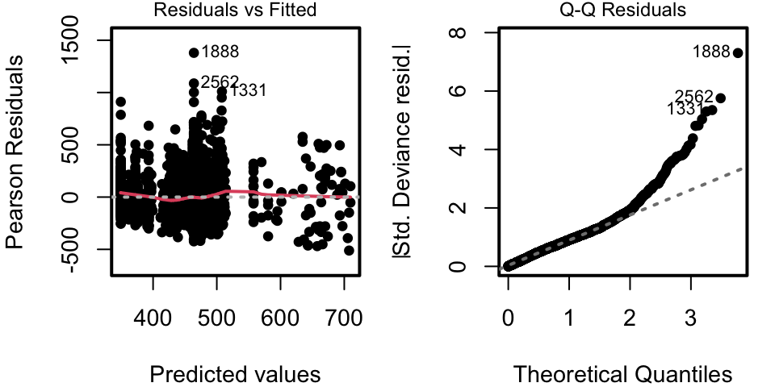

```r
# Fit a linear model
model1 <- glm(rent ~ yearc + location + yearc:location,
             data = munichrent,
             family = gaussian(link = 'identity'))

# Summarise the model
summary(model1)

Call:
glm(formula = rent ~ yearc + location + yearc:location, family = gaussian(link = "identity"),
    data = munichrent)

Coefficients:
                  Estimate Std. Error t value Pr(>|t|)
(Intercept)     -3.649e+03  4.215e+02  -8.658  < 2e-16 ***
yearc            2.085e+00  2.151e-01   9.692  < 2e-16 ***
location2        3.031e+03  6.174e+02   4.909 9.65e-07 ***
location3        2.120e+02  1.799e+03   0.118    0.906
yearc:location2 -1.520e+00  3.158e-01  -4.815 1.54e-06 ***
yearc:location3 -1.922e-03  9.199e-01  -0.002    0.998
---
Signif. codes:  0 '***' 0.001 '**' 0.01 '*' 0.05 '.' 0.1 ' ' 1

(Dispersion parameter for gaussian family taken to be 35786.03)

    Null deviance: 117945363  on 3081  degrees of freedom
Residual deviance: 110077841  on 3076  degrees of freedom
AIC: 41070

Number of Fisher Scoring iterations: 2

## Check residuals
par(mfrow=c(1,2),mar = c(4, 4, 1, 1),cex=1.2,lwd=2)
plot(model1,1,pch=20)
plot(model1,2,pch=20)
```

We can see that the model fit is quite poor, the QQ plot shows severe deviation from the line. The reason for that might be that rent prices are positive values and we are assuming a Normal GLM which might be inappropriate here. So lets change approach and model the rent prices using a Gamma GLM with an identity link

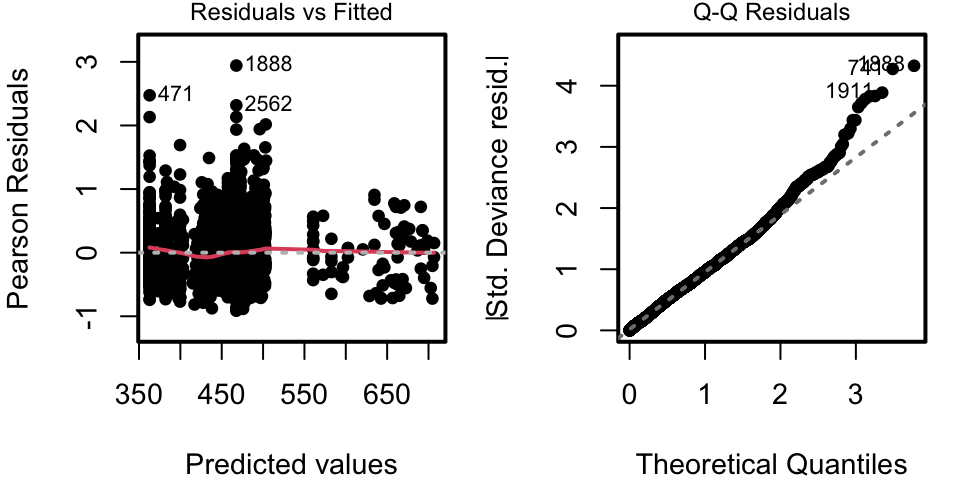

```r
# Fit a linear model
model2 <- glm(rent ~ yearc + location + yearc:location,
             data = munichrent,
             family = Gamma(link = 'identity'))

# Summarise the model
summary(model2)

Call:
glm(formula = rent ~ yearc + location + yearc:location, family = Gamma(link = "identity"),
    data = munichrent)

Coefficients:
                  Estimate Std. Error t value Pr(>|t|)
(Intercept)     -2997.4969   374.3483  -8.007 1.65e-15 ***
yearc               1.7520     0.1914   9.154  < 2e-16 ***
location2        2591.1048   601.6008   4.307 1.71e-05 ***
location3        -281.6856  2364.7076  -0.119    0.905
yearc:location2    -1.2963     0.3081  -4.208 2.66e-05 ***
yearc:location3     0.2500     1.2114   0.206    0.837
---
Signif. codes:  0 '***' 0.001 '**' 0.01 '*' 0.05 '.' 0.1 ' ' 1

(Dispersion parameter for Gamma family taken to be 0.1682382)

    Null deviance: 540.48  on 3081  degrees of freedom
Residual deviance: 506.61  on 3076  degrees of freedom
AIC: 40525

Number of Fisher Scoring iterations: 8

## Check residuals
par(mfrow=c(1,2),mar = c(4, 4, 1, 1),cex=1.2,lwd=2)
plot(model2,1,pch=20)
plot(model2,2,pch=20)
```

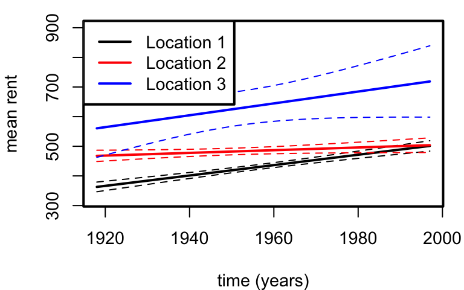

```r
## Look at predicted values for each location
years <- 1918:1997

# Predictions for our three types of location
loc1 <- predict(model2,newdata=data.frame(yearc=years,location=as.factor(1)),se.fit=T)
loc2 <- predict(model2,newdata=data.frame(yearc=years,location=as.factor(2)),se.fit=T)
loc3 <- predict(model2,newdata=data.frame(yearc=years,location=as.factor(3)),se.fit=T)

# Plot margins
par(mar = c(4, 4, 1, 1),cex=1.2,lwd=2)

# Predictions for location 1
plot(years,loc1$fit,type="l",ylim=c(320,900),xlab="time (years)",ylab="mean rent")
lines(years,loc1$fit+1.96*loc1$se.fit,lty=2,lwd=1)
lines(years,loc1$fit-1.96*loc1$se.fit,lty=2,lwd=1)

# Predictions for location 3
lines(years,loc2$fit,col="red")
lines(years,loc2$fit+1.96*loc2$se.fit,lty=2,lwd=1,col="red")
lines(years,loc2$fit-1.96*loc2$se.fit,lty=2,lwd=1,col="red")

# Predictions for location 3
lines(years,loc3$fit,col="blue")
lines(years,loc3$fit+1.96*loc3$se.fit,lty=2,lwd=1,col="blue")
lines(years,loc3$fit-1.96*loc3$se.fit,lty=2,lwd=1,col="blue")

# add a legend
legend("topleft",c("Location 1","Location 2","Location 3"),col=c("black","red","blue"),lty=c(1,1,1))
```

This is a very simple extension to include interactions between smooth functions and factors, as we can use the `by=` argument within the function `s()`.

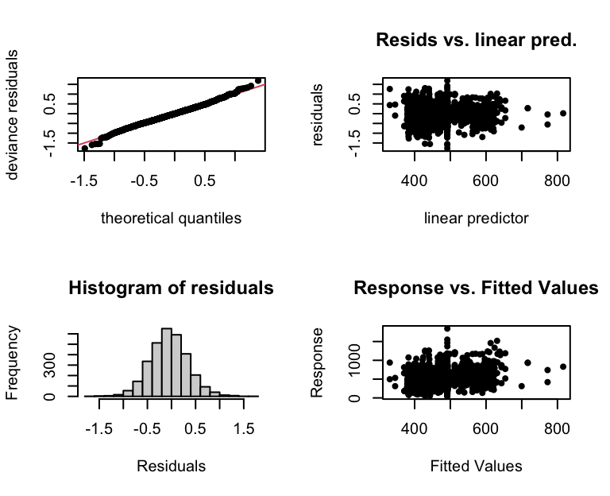

```
Method: GCV   Optimizer: outer newton
full convergence after 7 iterations.
Gradient range [-6.196702e-08,-1.398099e-10]
(score 0.158839 & scale 0.158635).
Hessian positive definite, eigenvalue range [1.545612e-05,5.196687e-05].
Model rank =  28 / 28

Basis dimension (k) checking results. Low p-value (k-index<1) may
indicate that k is too low, especially if edf is close to k'.

                     k'  edf k-index p-value
s(yearc):location1 9.00 6.19    0.95   0.030 *
s(yearc):location2 9.00 4.80    0.95   0.035 *
s(yearc):location3 9.00 8.77    0.95   0.040 *
---
Signif. codes:  0 '***' 0.001 '**' 0.01 '*' 0.05 '.' 0.1 ' ' 1
```

```r
# Fit as a GAM
model3 <- gam(rent ~ s(yearc, by = location, k = 10),
              data = munichrent,
              family = Gamma(link="identity"))

# Checking residuals
par(mfrow=c(2,2))
gam.check(model3,pch=20)
```

We can see that the residual plots are looking much better here. The QQ plot follows the indicated line. The residual plot may show a little funnelling (more variable for older houses). In terms of the degrees of freedom for the function, we see that the table now shows three functions, one for each location. The first two of these functions look like they have enough flexibility as the EDF is not close to $k'$, but the third function looks like it may need more flexibility as the EDF is close to $k'$. Let’s fit this model again with a higher rank in our functions.

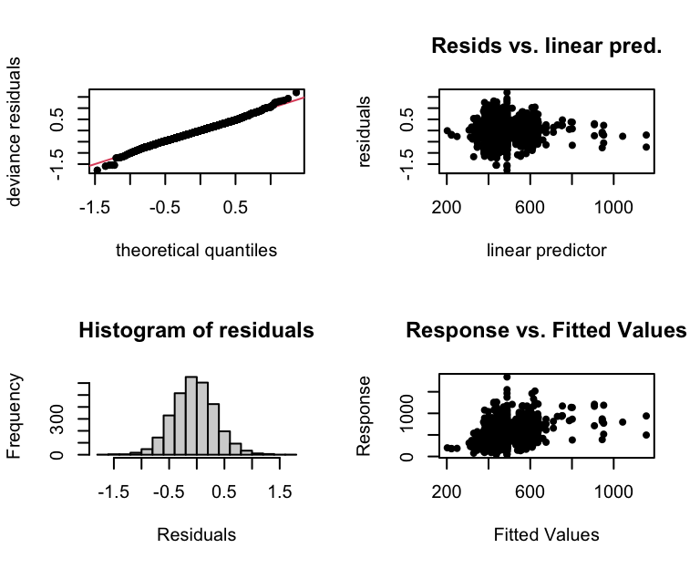

```
Method: GCV   Optimizer: outer newton
full convergence after 8 iterations.
Gradient range [-3.028315e-10,2.43314e-07]
(score 0.1563286 & scale 0.1540028).
Hessian positive definite, eigenvalue range [2.56165e-05,0.0001478237].
Model rank =  88 / 88

Basis dimension (k) checking results. Low p-value (k-index<1) may
indicate that k is too low, especially if edf is close to k'.

                      k'   edf k-index p-value
s(yearc):location1 29.00 16.25    0.96    0.08 .
s(yearc):location2 29.00  5.54    0.96    0.08 .
s(yearc):location3 29.00 25.97    0.96    0.12
---
Signif. codes:  0 '***' 0.001 '**' 0.01 '*' 0.05 '.' 0.1 ' ' 1
```

```r
# Fit as a GAM
model3 <- gam(rent ~ s(yearc, by = location, k = 30),
              data = munichrent,
              family = Gamma(link="identity"))

# Checking residuals
par(mfrow=c(2,2))
gam.check(model3,pch=20)
```

Residuals looking acceptable, but not perfect. QQ plot suggests perhaps we’re not doing particularly well in the tails and there still may be some funnelling in the residual plots. We can see now that the model has enough have enough flexibility as the EDF is not close to $k'$ for all functions. Let’s predict from this model

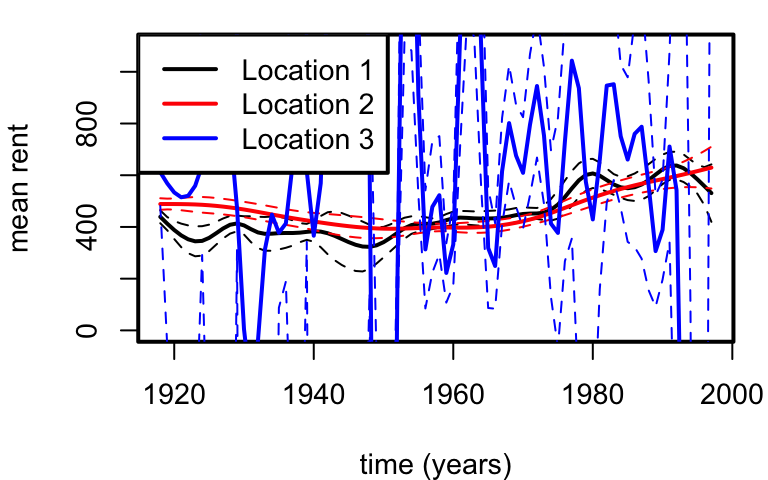

```r
## Look at predicted values for each location
years <- 1918:1997

# Predictions for our three types of location
loc1 <- predict(model3,newdata=data.frame(yearc=years,location=as.factor(1)),se.fit=T)
loc2 <- predict(model3,newdata=data.frame(yearc=years,location=as.factor(2)),se.fit=T)
loc3 <- predict(model3,newdata=data.frame(yearc=years,location=as.factor(3)),se.fit=T)

# Plot margins
par(mar = c(4, 4, 1, 1),cex=1.2,lwd=2)

# Predictions for location 1
plot(years,loc1$fit,type="l",ylim=c(0,1100),xlab="time (years)",ylab="mean rent")
lines(years,loc1$fit+1.96*loc1$se.fit,lty=2,lwd=1)
lines(years,loc1$fit-1.96*loc1$se.fit,lty=2,lwd=1)

# Predictions for location 3
lines(years,loc2$fit,col="red")
lines(years,loc2$fit+1.96*loc2$se.fit,lty=2,lwd=1,col="red")
lines(years,loc2$fit-1.96*loc2$se.fit,lty=2,lwd=1,col="red")

# Predictions for location 3
lines(years,loc3$fit,col="blue")
lines(years,loc3$fit+1.96*loc3$se.fit,lty=2,lwd=1,col="blue")
lines(years,loc3$fit-1.96*loc3$se.fit,lty=2,lwd=1,col="blue")

# add a legend
legend("topleft",c("Location 1","Location 2","Location 3"),col=c("black","red","blue"),lty=c(1,1,1))
```

This looks a mess. Locations 1 and 2 look acceptable, but location 3 is all over the place. We probably don’t believe that there is that much variability in the data for location 3. It also predicts negative values for the rent, which is nonsense. Why is this happening? The answer is that we chose the identity link. The model we have just fit is
$$Y_i \sim Gamma(\mu_i, \sigma^2)$$
$$\eta_i = \mu_i = \beta_0 + f_1(x_i) + f_2(x_i) +
f_3(x_i)$$
where $y_i$ is the rent price, $x_i$ is the year of construction and $f_1(\cdot)$, $f_2(\cdot)$ and $f_3(\cdot)$ are functions of $x_i$ for each location index. There is nothing in this that will constrain $\mu_i$ to be positive so it predicts negative values. This would also be the case if we used the inverse link
$$\eta_i = \frac{1}{\mu_i} = \beta_0 +
f_1(x_i) + f_2(x_i) + f_3(x_i)$$
You will often see this that outside the range of the data (and where you have little data). In some cases we may need to reconsider our approach and change the link function to avoid problems like this. If we need something to be positive we use the log link, exactly like in Poisson models.
$$\eta_i = \log(\mu_i) = \beta_0 + f_1(x_i) +
f_2(x_i) + f_3(x_i)$$
Let’s rerun our model with a log link.

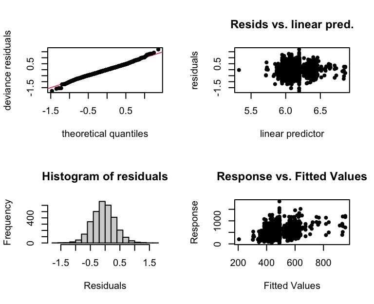

```
Method: GCV   Optimizer: outer newton
full convergence after 6 iterations.
Gradient range [7.932475e-11,6.793248e-08]
(score 0.1565134 & scale 0.1539737).
Hessian positive definite, eigenvalue range [1.575059e-05,0.0001431348].
Model rank =  88 / 88

Basis dimension (k) checking results. Low p-value (k-index<1) may
indicate that k is too low, especially if edf is close to k'.

                     k'  edf k-index p-value
s(yearc):location1 29.0 15.1    0.96   0.090 .
s(yearc):location2 29.0  6.5    0.96   0.075 .
s(yearc):location3 29.0 25.9    0.96   0.070 .
---
Signif. codes:  0 '***' 0.001 '**' 0.01 '*' 0.05 '.' 0.1 ' ' 1
```

```r
# Fit as a GAM
model3 <- gam(rent ~ s(yearc, by = location, k = 30),
              data = munichrent,
              family = Gamma(link="log"))

# Checking residuals
par(mfrow=c(2,2))
gam.check(model3,pch=20)
```

The residual plots haven’t really changed. QQ plot suggests perhaps we’re not doing particularly well in the tails and there still may be some funnelling in the residual plots. The smooth functions still have enough flexibility so lets predict from this model.

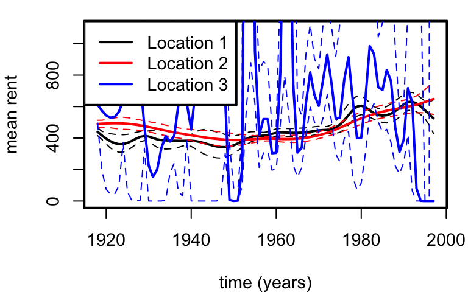

```r
## Look at predicted values for each location
years <- 1918:1997

# Predictions for our three types of location
loc1 <- predict(model3,newdata=data.frame(yearc=years,location=as.factor(1)),se.fit=T)
loc2 <- predict(model3,newdata=data.frame(yearc=years,location=as.factor(2)),se.fit=T)
loc3 <- predict(model3,newdata=data.frame(yearc=years,location=as.factor(3)),se.fit=T)

# Plot margins
par(mar = c(4, 4, 1, 1),cex=1.2,lwd=2)

# Predictions for location 1
plot(years,exp(loc1$fit),type="l",ylim=c(0,1100),xlab="time (years)",ylab="mean rent")
lines(years,exp(loc1$fit+1.96*loc1$se.fit),lty=2,lwd=1)
lines(years,exp(loc1$fit-1.96*loc1$se.fit),lty=2,lwd=1)

# Predictions for location 3
lines(years,exp(loc2$fit),col="red")
lines(years,exp(loc2$fit+1.96*loc2$se.fit),lty=2,lwd=1,col="red")
lines(years,exp(loc2$fit-1.96*loc2$se.fit),lty=2,lwd=1,col="red")

# Predictions for location 3
lines(years,exp(loc3$fit),col="blue")
lines(years,exp(loc3$fit+1.96*loc3$se.fit),lty=2,lwd=1,col="blue")
lines(years,exp(loc3$fit-1.96*loc3$se.fit),lty=2,lwd=1,col="blue")

# add a legend
legend("topleft",c("Location 1","Location 2","Location 3"),col=c("black","red","blue"),lty=c(1,1,1))
```

The log link now has stopped negative values, but the smooth function for location 3 still looks too flexible. It is hard to imagine that rent prices vary by that much over the year of construction. This can happen when you give a function too many degrees of freedom when you don’t have enough data. Let’s look at the distribution of houses by location index

```r
# Table of location index
table(munichrent$location)

   1    2    3
1794 1210   78
```

We can see that we have a lot less apartments in location 3 than we have in locations 1 and 2. Let’s look at a summary of rent prices

```r
# Table of location index
summary(munichrent$rent)
   Min. 1st Qu.  Median    Mean 3rd Qu.    Max.
  40.51  322.03  426.97  459.44  559.36 1843.38
```

If we look at the model, the mean suggests the rent can go above the maximum and below the minimum. So this is an example where we should use subjective reasoning about having degrees of freedom in our smooth functions (despite the outputs from `gam.check()`). Remember `gam.check()` does not understand the context of your problem, nor does it know if some predicted values are reasonable or not, it is there to indicate that you *may* need to alter things. So lets go back a step and put a lower rank of our functions, less than say `gam.check()` would be “happy” with to see if we fit the data better.

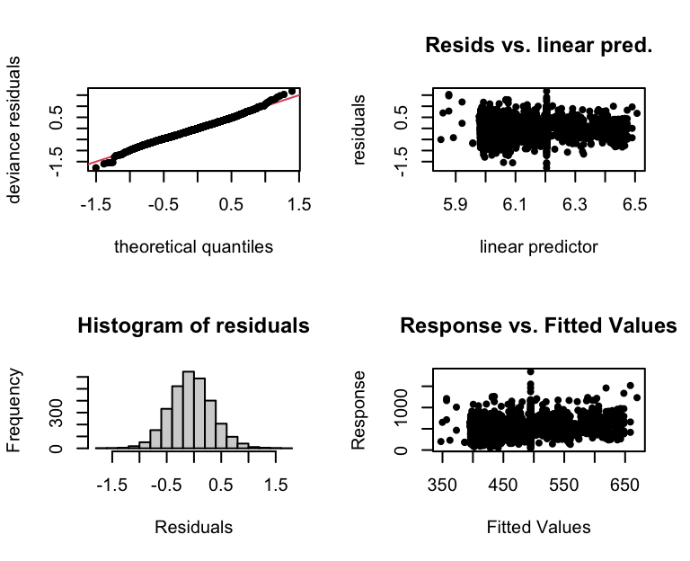

```
Method: GCV   Optimizer: outer newton
full convergence after 5 iterations.
Gradient range [-4.014016e-11,4.055574e-08]
(score 0.1596586 & scale 0.1612285).
Hessian positive definite, eigenvalue range [1.824618e-05,7.578975e-05].
Model rank =  13 / 13

Basis dimension (k) checking results. Low p-value (k-index<1) may
indicate that k is too low, especially if edf is close to k'.

                     k'  edf k-index p-value
s(yearc):location1 4.00 2.81    0.95   0.020 *
s(yearc):location2 4.00 3.24    0.95   0.040 *
s(yearc):location3 4.00 3.76    0.95   0.015 *
---
Signif. codes:  0 '***' 0.001 '**' 0.01 '*' 0.05 '.' 0.1 ' ' 1
```

```r
# Fit as a GAM
model3 <- gam(rent ~ s(yearc, by = location, k = 5),
              data = munichrent,
              family = Gamma(link="log"))

# Checking residuals
par(mfrow=c(2,2))
gam.check(model3,pch=20)
```

The residual plots look OK actually in this case, better than before arguably. The QQ plot looks OK, with some deviation in the tails, but we don’t have a lot of data in the extremes. The funneling seems to have disappeared from the residual plots. Some room for improvement but they’re acceptable. Let’s predict from this model.

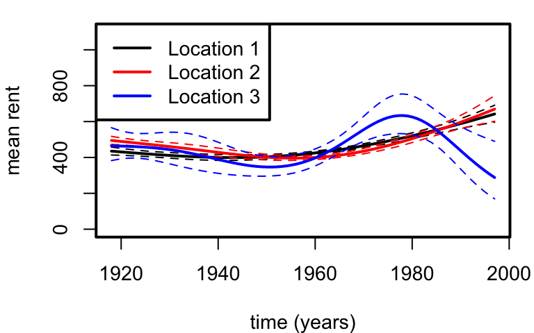

```r
## Look at predicted values for each location
years <- 1918:1997

# Predictions for our three types of location
loc1 <- predict(model3,newdata=data.frame(yearc=years,location=as.factor(1)),se.fit=T)
loc2 <- predict(model3,newdata=data.frame(yearc=years,location=as.factor(2)),se.fit=T)
loc3 <- predict(model3,newdata=data.frame(yearc=years,location=as.factor(3)),se.fit=T)

# Plot margins
par(mar = c(4, 4, 1, 1),cex=1.2,lwd=2)

# Predictions for location 1
plot(years,exp(loc1$fit),type="l",ylim=c(0,1100),xlab="time (years)",ylab="mean rent")
lines(years,exp(loc1$fit+1.96*loc1$se.fit),lty=2,lwd=1)
lines(years,exp(loc1$fit-1.96*loc1$se.fit),lty=2,lwd=1)

# Predictions for location 3
lines(years,exp(loc2$fit),col="red")
lines(years,exp(loc2$fit+1.96*loc2$se.fit),lty=2,lwd=1,col="red")
lines(years,exp(loc2$fit-1.96*loc2$se.fit),lty=2,lwd=1,col="red")

# Predictions for location 3
lines(years,exp(loc3$fit),col="blue")
lines(years,exp(loc3$fit+1.96*loc3$se.fit),lty=2,lwd=1,col="blue")
lines(years,exp(loc3$fit-1.96*loc3$se.fit),lty=2,lwd=1,col="blue")

# add a legend
legend("topleft",c("Location 1","Location 2","Location 3"),col=c("black","red","blue"),lty=c(1,1,1))
```

We can see now that the model is predicting reasonable values of rent within the range of the data. We can interpret these now and that locations 1 and 2 have lower rents for older houses than rents for newer houses. It suggests that the relationship is non-linear. Location 3 seems to be highly non-linear and suggests that you pay more rent in houses built in the 1970s than any other time. This may be reasonable, but we may need some expert knowledge. But note that we have significantly less data for location 3 than 1 or 2 so it may be the case we don’t have enough data to estimate this relationship reliably. OR it maybe that affluent areas are much less likely to rent. OR it maybe the case that less modern houses are being built in affluent areas. It will depend on the context of your problem.